# GOT

created on 19 MARCH 2025 and updated 19 March, 2025

**Note:** for more text analysis, you can fork & work through Casey O’Hara and Jessica Couture’s eco-data-sci workshop (available here https://github.com/oharac/text_workshop)

### Get the GOT text:

```r
GOT_path <- here("data","got.pdf")
GOT_text <- pdf_text(GOT_path)
```

Some things to notice:

- How cool to extract text out of a PDF! Do you think it will work with any PDF?
- Each row is a page of the PDF (i.e., this is a vector of strings, one for each page)
- The pdf_text() function only sees text that is “selectable”

From Jessica and Casey’s text mining workshop: “pdf_text() returns a vector of strings, one for each page of the pdf. So we can mess with it in tidyverse style, let’s turn it into a dataframe, and keep track of the pages. Then we can use stringr::str_split() to break the pages up into individual lines. Each line of the pdf is concluded with a backslash-n, so split on this. We will also add a line number in addition to the page number.”

### Some wrangling:

- Split up pages into separate lines (separated by `\n`) using `stringr::str_split()`
- Unnest into regular columns using `tidyr::unnest()`
- Remove leading/trailing white space with `stringr::str_trim()`

```r
GOT_df <- data.frame(GOT_text) %>%
  mutate(text_full = str_split(GOT_text, pattern = '\n')) %>%
  unnest(text_full) %>%
  mutate(text_full = str_trim(text_full))


GOT_df
```

```
## # A tibble: 30,233 × 2
##    GOT_text                                                            text_full
##    <chr>                                                               <chr>
##  1 ""                                                                  ""
##  2 "                  A GAME OF THRONES\n\n\n            Book One of … "A GAME …
##  3 "                  A GAME OF THRONES\n\n\n            Book One of … ""
##  4 "                  A GAME OF THRONES\n\n\n            Book One of … ""
##  5 "                  A GAME OF THRONES\n\n\n            Book One of … "Book On…
##  6 "                  A GAME OF THRONES\n\n\n            Book One of … ""
##  7 "                  A GAME OF THRONES\n\n\n            Book One of … ""
##  8 "                  A GAME OF THRONES\n\n\n            Book One of … "By Geor…
##  9 "                  A GAME OF THRONES\n\n\n            Book One of … "Content…
## 10 "                  A GAME OF THRONES\n\n\n            Book One of … "Maps"
## # ℹ 30,223 more rows
```

Now each line, on each page, is its own row, with extra starting & trailing spaces removed.

### Get the tokens (individual words) in tidy format

Use `tidytext::unnest_tokens()` (which pulls from the `tokenizer`) package, to split columns into tokens. We are interested in *words*, so that’s the token we’ll use:

```r
GOT_tokens <- GOT_df %>%
  unnest_tokens(word, text_full)
GOT_tokens
```

```
## # A tibble: 297,814 × 2
##    GOT_text                                                                word
##    <chr>                                                                   <chr>
##  1 "                  A GAME OF THRONES\n\n\n            Book One of A So… a
##  2 "                  A GAME OF THRONES\n\n\n            Book One of A So… game
##  3 "                  A GAME OF THRONES\n\n\n            Book One of A So… of
##  4 "                  A GAME OF THRONES\n\n\n            Book One of A So… thro…
##  5 "                  A GAME OF THRONES\n\n\n            Book One of A So… book
##  6 "                  A GAME OF THRONES\n\n\n            Book One of A So… one
##  7 "                  A GAME OF THRONES\n\n\n            Book One of A So… of
##  8 "                  A GAME OF THRONES\n\n\n            Book One of A So… a
##  9 "                  A GAME OF THRONES\n\n\n            Book One of A So… song
## 10 "                  A GAME OF THRONES\n\n\n            Book One of A So… of
## # ℹ 297,804 more rows
```

Let’s count the words!

```r
GOT_wc <- GOT_tokens %>%
  count(word) %>%
  arrange(-n)
GOT_wc
```

```
## # A tibble: 11,826 × 2
##    word      n
##    <chr> <int>
##  1 the   17988
##  2 and    8997
##  3 to     6640
##  4 a      6461
##  5 of     6200
##  6 he     5166
##  7 his    5161
##  8 was    3904
##  9 her    3659
## 10 you    3267
## # ℹ 11,816 more rows
```

OK…so we notice that a whole bunch of things show up frequently that we might not be interested in (“a”, “the”, “and”, etc.). These are called *stop words*. Let’s remove them.

### Remove stop words:

See `?stop_words` and `View(stop_words)`to look at documentation for stop words lexicons.

We will *remove* stop words using `tidyr::anti_join()`:

```r
stop_words
```

```
## # A tibble: 1,149 × 2
##    word        lexicon
##    <chr>       <chr>
##  1 a           SMART
##  2 a's         SMART
##  3 able        SMART
##  4 about       SMART
##  5 above       SMART
##  6 according   SMART
##  7 accordingly SMART
##  8 across      SMART
##  9 actually    SMART
## 10 after       SMART
## # ℹ 1,139 more rows
```

```r
GOT_stop <- GOT_tokens %>%
  anti_join(stop_words) %>%
  select(-GOT_text)
```

Now check the counts again:

```r
GOT_swc <- GOT_stop %>%
  count(word) %>%
  arrange(-n)
GOT_swc
```

```
## # A tibble: 11,295 × 2
##    word       n
##    <chr>  <int>
##  1 lord    1341
##  2 ser     1023
##  3 jon      787
##  4 ned      743
##  5 tyrion   591
##  6 eyes     567
##  7 hand     567
##  8 king     542
##  9 father   512
## 10 told     504
## # ℹ 11,285 more rows
```

What if we want to get rid of all the numbers (non-text) in `GOT stop`?

```r
# This code will filter out numbers by asking:
# If you convert to as.numeric, is it NA (meaning those words)?
# If it IS NA (is.na), then keep it (so all words are kept)
# Anything that is converted to a number is removed

GOT_no_numeric <- GOT_stop %>%
  filter(is.na(as.numeric(word)))
```

### A word cloud of GOT text (non-numeric)

See more: https://cran.r-project.org/web/packages/ggwordcloud/vignettes/ggwordcloud.html

```r
# There are over 11.000 unique words
length(unique(GOT_no_numeric$word))
```

```
## [1] 11209
```

```r
# We probably don't want to include them all in a word cloud. Let's filter to only include the top 100 most frequent?
GOT_top100 <- GOT_no_numeric %>%
  count(word) %>%
  arrange(-n) %>%
  head(100)
GOT_top100
```

```
## # A tibble: 100 × 2
##    word       n
##    <chr>  <int>
##  1 lord    1341
##  2 ser     1023
##  3 jon      787
##  4 ned      743
##  5 tyrion   591
##  6 eyes     567
##  7 hand     567
##  8 king     542
##  9 father   512
## 10 told     504
## # ℹ 90 more rows
```

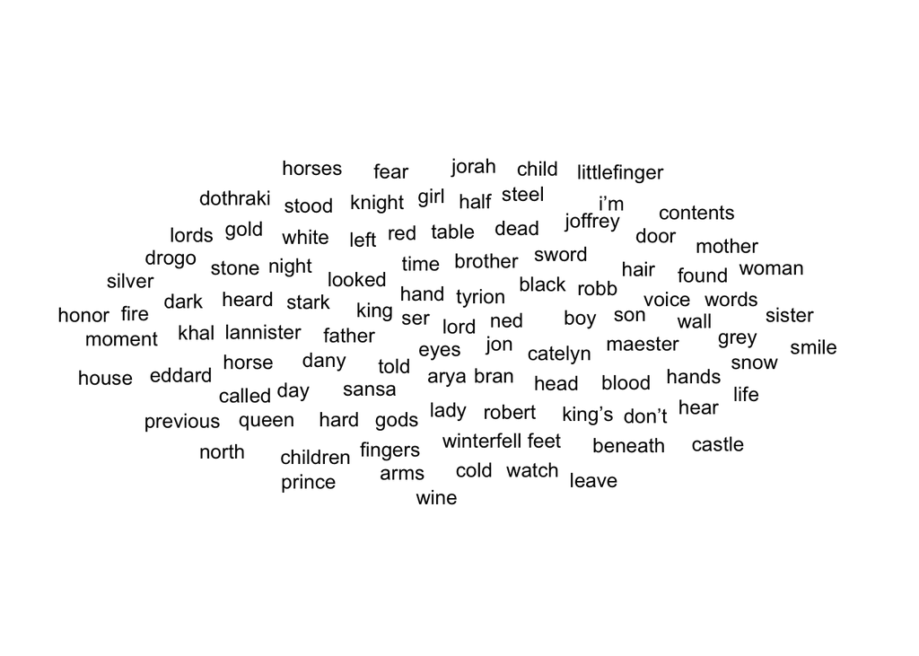

```r
GOT_cloud <- ggplot(data = GOT_top100, aes(label = word)) +
  geom_text_wordcloud() +
  theme_minimal()

GOT_cloud
```

That’s underwhelming. Let’s customize it a bit:

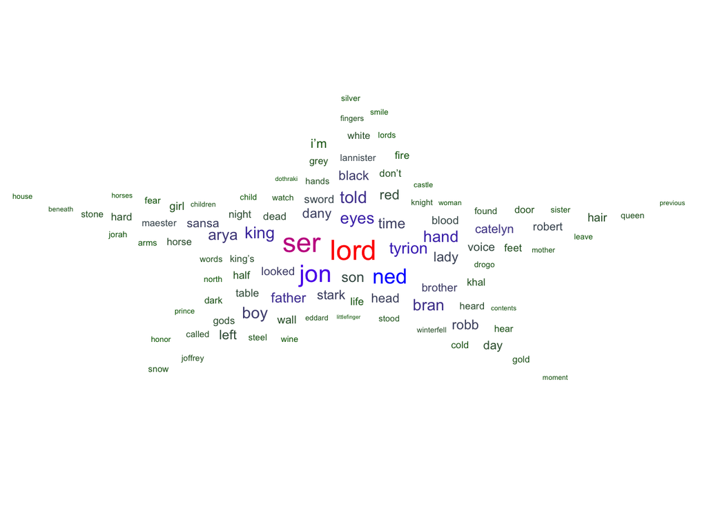

```r
ggplot(data = GOT_top100, aes(label = word, size = n)) +
  geom_text_wordcloud_area(aes(color = n), shape = "star") +
  scale_size_area(max_size = 12) +
  scale_color_gradientn(colors = c("darkgreen","blue","red")) +
  theme_minimal()
```

Cool! And you can facet wrap (for different reports, for example) and update other aesthetics. See more here: https://cran.r-project.org/web/packages/ggwordcloud/vignettes/ggwordcloud.html

### Sentiment analysis

First, check out the ‘sentiments’ lexicon. From Julia Silge and David Robinson (https://www.tidytextmining.com/sentiment.html):

“The three general-purpose lexicons are

- AFINN from Finn Årup Nielsen,
- bing from Bing Liu and collaborators, and
- nrc from Saif Mohammad and Peter Turney

All three of these lexicons are based on unigrams, i.e., single words. These lexicons contain many English words and the words are assigned scores for positive/negative sentiment, and also possibly emotions like joy, anger, sadness, and so forth. The AFINN lexicon assigns words with a score that runs between -5 and 5, with negative scores indicating negative sentiment and positive scores indicating positive sentiment. The bing lexicon categorizes words in a binary fashion into positive and negative categories. The nrc lexicon categorizes words in a binary fashion (“yes”/“no”) into categories of positive, negative, anger, anticipation, disgust, fear, joy, sadness, surprise, and trust. All of this information is tabulated in the sentiments dataset, and tidytext provides a function get_sentiments() to get specific sentiment lexicons without the columns that are not used in that lexicon.”

Let’s explore the sentiment lexicons. “bing” is included, other lexicons (“afinn”, “nrc”, “loughran”) you’ll be prompted to download.

**WARNING:** These collections include very offensive words. I urge you to not look at them in class.

“afinn”: Words ranked from -5 (very negative) to +5 (very positive)

```r
get_sentiments(lexicon = "afinn")
```

```
## # A tibble: 2,477 × 2
##    word       value
##    <chr>      <dbl>
##  1 abandon       -2
##  2 abandoned     -2
##  3 abandons      -2
##  4 abducted      -2
##  5 abduction     -2
##  6 abductions    -2
##  7 abhor         -3
##  8 abhorred      -3
##  9 abhorrent     -3
## 10 abhors        -3
## # ℹ 2,467 more rows
```

```r
# Note: may be prompted to download (yes)

# Let's look at the pretty positive words:
afinn_pos <- get_sentiments("afinn") %>%
  filter(value %in% c(3,4,5))

# Do not look at negative words in class.
afinn_pos
```

```
## # A tibble: 222 × 2
##    word         value
##    <chr>        <dbl>
##  1 admire           3
##  2 admired          3
##  3 admires          3
##  4 admiring         3
##  5 adorable         3
##  6 adore            3
##  7 adored           3
##  8 adores           3
##  9 affection        3
## 10 affectionate     3
## # ℹ 212 more rows
```

bing: binary, “positive” or “negative”

```r
get_sentiments(lexicon = "bing")
```

```
## # A tibble: 6,786 × 2
##    word        sentiment
##    <chr>       <chr>
##  1 2-faces     negative
##  2 abnormal    negative
##  3 abolish     negative
##  4 abominable  negative
##  5 abominably  negative
##  6 abominate   negative
##  7 abomination negative
##  8 abort       negative
##  9 aborted     negative
## 10 aborts      negative
## # ℹ 6,776 more rows
```

nrc:https://saifmohammad.com/WebPages/NRC-Emotion-Lexicon.htm Includes bins for 8 emotions (anger, anticipation, disgust, fear, joy, sadness, surprise, trust) and positive / negative.

**Citation for NRC lexicon**: Crowdsourcing a Word-Emotion Association Lexicon, Saif Mohammad and Peter Turney, Computational Intelligence, 29 (3), 436-465, 2013.

Now nrc:

```r
get_sentiments(lexicon = "nrc")
```

```
## # A tibble: 13,872 × 2
##    word        sentiment
##    <chr>       <chr>
##  1 abacus      trust
##  2 abandon     fear
##  3 abandon     negative
##  4 abandon     sadness
##  5 abandoned   anger
##  6 abandoned   fear
##  7 abandoned   negative
##  8 abandoned   sadness
##  9 abandonment anger
## 10 abandonment fear
## # ℹ 13,862 more rows
```

### Sentiment analysis with afinn:

```r
GOT_afinn <- GOT_stop %>%
  inner_join(get_sentiments("afinn"))
GOT_afinn
```

```
## # A tibble: 13,058 × 2
##    word  value
##    <chr> <dbl>
##  1 fire     -2
##  2 dead     -3
##  3 dead     -3
##  4 smile     2
##  5 dead     -3
##  6 dead     -3
##  7 dead     -3
##  8 dead     -3
##  9 dead     -3
## 10 drag     -1
## # ℹ 13,048 more rows
```

Let’s find some counts (by sentiment ranking):

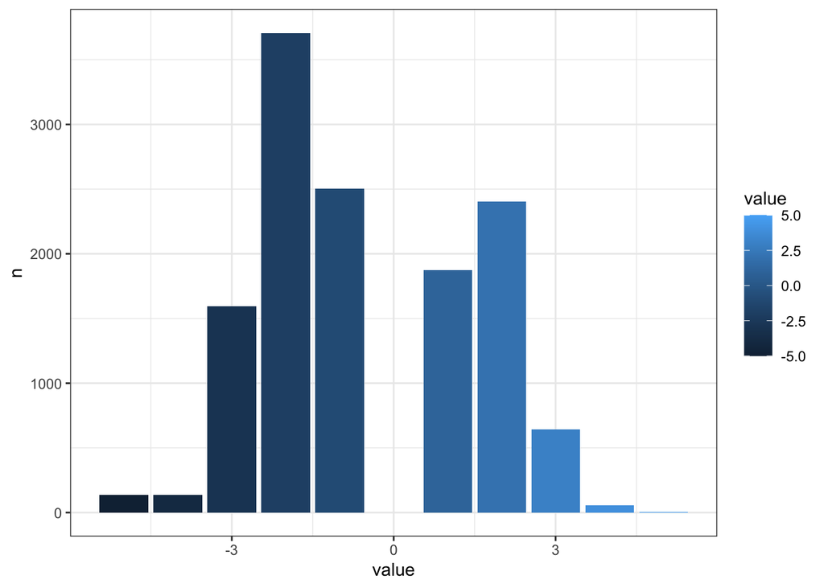

```r
GOT_afinn_hist <- GOT_afinn %>%
  count(value)

# Plot them:
ggplot(data = GOT_afinn_hist, aes(x = value, y = n)) +
  geom_col(aes(fill = value)) +
  theme_bw()
```

Investigate some of the words in a bit more depth:

```r
# What are these '2' words?
GOT_afinn2 <- GOT_afinn %>%
  filter(value == 2)
GOT_afinn2
```

```
## # A tibble: 2,405 × 2
##    word     value
##    <chr>    <dbl>
##  1 smile        2
##  2 fine         2
##  3 glory        2
##  4 hope         2
##  5 smiled       2
##  6 care         2
##  7 strength     2
##  8 peaceful     2
##  9 smile        2
## 10 smile        2
## # ℹ 2,395 more rows
```

```r
# Check the unique 2-score words:
unique(GOT_afinn2$word)
```

```
##   [1] "smile"           "fine"            "glory"           "hope"
##   [5] "smiled"          "care"            "strength"        "peaceful"
##   [9] "honor"           "carefully"       "slick"           "top"
##  [13] "gained"          "comfort"         "sweet"           "courage"
##  [17] "daring"          "elegant"         "justice"         "heroes"
##  [21] "fair"            "strong"          "brave"           "solid"
##  [25] "proud"           "mercy"           "rescue"          "swift"
##  [29] "smiling"         "true"            "noble"           "saved"
##  [33] "gift"            "treasures"       "favorite"        "clean"
##  [37] "rich"            "fearless"        "fortunate"       "likes"
##  [41] "earnest"         "generous"        "chances"         "smiles"
##  [45] "hug"             "kiss"            "approved"        "fond"
##  [49] "honored"         "consent"         "peace"           "powerful"
##  [53] "worthy"          "humor"           "entertaining"    "save"
##  [57] "sincerely"       "festive"         "careful"         "stronger"
```

[output cut: 36 more lines]

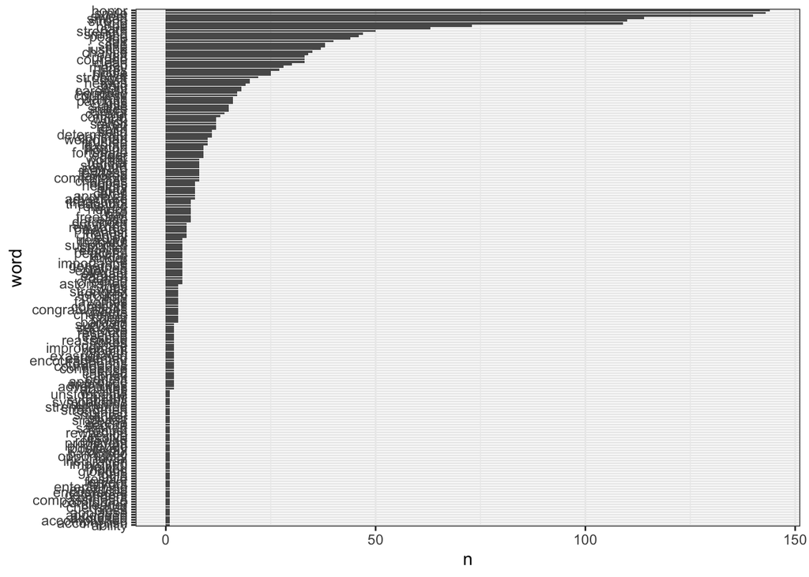

```r
# Count & plot them
GOT_afinn2_n <- GOT_afinn2 %>%
  count(word, sort = TRUE) %>%
  mutate(word = fct_reorder(factor(word), n))


ggplot(data = GOT_afinn2_n, aes(x = word, y = n)) +
  geom_col() +
  coord_flip() +
  theme_bw()
```

We learn something important from this example: Just using a sentiment lexicon to match words will not differentiate between different uses of the word…(ML can start figuring it out with context, but we won’t do that here).

Or we can summarize sentiment for the report:

```r
GOT_summary <- GOT_afinn %>%
  summarize(
    mean_score = mean(value),
    median_score = median(value))
GOT_summary
```

```
## # A tibble: 1 × 2
##   mean_score median_score
##        <dbl>        <dbl>
## 1     -0.542           -1
```

The mean and median indicate *slightly* NEGATIVE overall sentiments based on the AFINN lexicon.

### NRC lexicon for sentiment analysis

We can use the NRC lexicon to start “binning” text by the feelings they’re typically associated with. As above, we’ll use inner_join() to combine the GOT non-stopword text with the nrc lexicon:

```r
GOT_nrc <- GOT_stop %>%
  inner_join(get_sentiments("nrc"))
```

Wait, won’t that exclude some of the words in our text? YES! We should check which are excluded using `anti_join()`:

```r
GOT_exclude <- GOT_stop %>%
  anti_join(get_sentiments("nrc"))


# Count to find the most excluded:
GOT_exclude_n <- GOT_exclude %>%
  count(word, sort = TRUE)

head(GOT_exclude_n)
```

```
## # A tibble: 6 × 2
##   word       n
##   <chr>  <int>
## 1 ser     1023
## 2 jon      787
## 3 ned      743
## 4 tyrion   591
## 5 eyes     567
## 6 hand     567
```

**Lesson: always check which words are EXCLUDED in sentiment analysis using a pre-built lexicon!**

Now find some counts:

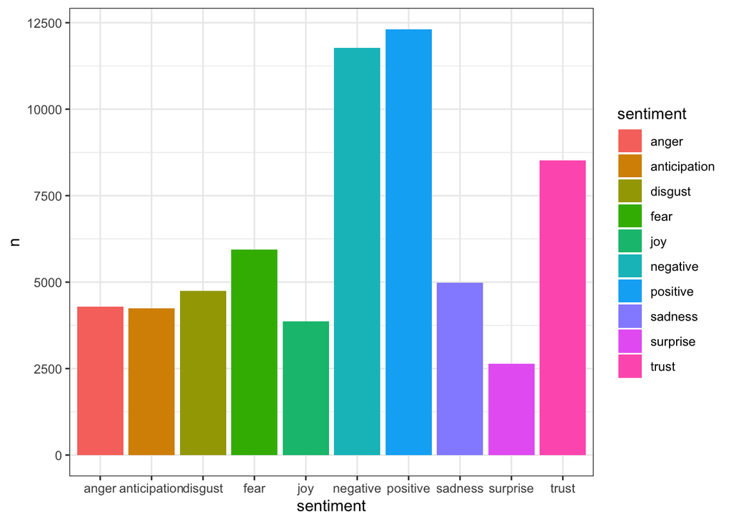

```r
GOT_nrc_n <- GOT_nrc %>%
  count(sentiment, sort = TRUE)

# And plot them:

ggplot(data = GOT_nrc_n, aes(x = sentiment, y = n)) +
  geom_col(aes(fill = sentiment))+
  theme_bw()
```

Or count by sentiment *and* word, then facet:

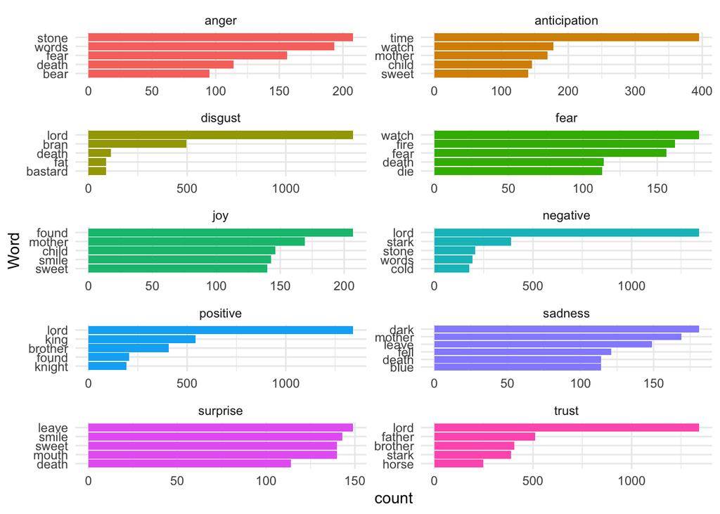

```r
GOT_nrc_n5 <- GOT_nrc %>%
  count(word,sentiment, sort = TRUE) %>%
  group_by(sentiment) %>%
  top_n(5) %>%
  ungroup()

GOT_nrc_gg <- ggplot(data = GOT_nrc_n5, aes(x = reorder(word,n), y = n, fill = sentiment)) +
  geom_col(show.legend = FALSE) +
  facet_wrap(~sentiment, ncol = 2, scales = "free") +
  coord_flip() +
  theme_minimal() +
  labs(x = "Word", y = "count")

# Show it
GOT_nrc_gg
```

```r
# Save it
ggsave(plot = GOT_nrc_gg,
       here("figures","ipcc_nrc_sentiment.png"),
       height = 8,
       width = 5)
```

```r
conf <- get_sentiments(lexicon = "nrc") %>%
  filter(word == "confidence")

# Yep, check it out:
conf
```

```
## # A tibble: 4 × 2
##   word       sentiment
##   <chr>      <chr>
## 1 confidence fear
## 2 confidence joy
## 3 confidence positive
## 4 confidence trust
```

## Big picture takeaway

There are serious limitations of sentiment analysis using existing lexicons, and you should **think really hard** about your findings and if a lexicon makes sense for your study. Otherwise, word counts and exploration alone can be useful!

## Your task

Taking this script as a point of departure, apply sentiment analysis on the Game of Thrones. You will find a pdf in the data folder. What are the most common meaningful words and what emotions do you expect will dominate this volume? Are there any terms that are similarly ambiguous to the ‘confidence’ above?

### Credits:

This tutorial is inspired by Allison Horst’s Advanced Statistics and Data Analysis.